# Bayesian Conditional Autoregression Models in “rjags”

Sudipto Banerjee

2023-10-10

0. The root directory for this project has 3 subfolders: “data”, “src” and “test”. This Rmd file is in the “test” directory. The “data” directory contains the data sets for this spatial example. The “src” directory contains a JAGS model in the “model_jags_arealModeling.txt” file and an R program called “data_prep_arealModeling.R” to prepare the data in JAGS format.
1. Remove all objects from R workspace—good programming practice and can help debug your code better.

```r
rm(list = ls())
```

2. Load “rjags” and “coda” packages

```r
library(rjags)
library(coda)
```

3. Prepare the data by running the “data_prep.R” file in the “src” directory.

```r
source("../src/data_prep_arealModeling.R")
```

[output not shown]

```
## To access larger datasets in this package, install the spDataLarge
## package with: `install.packages('spDataLarge',
## repos='https://nowosad.github.io/drat/', type='source')`
```

```
## Spherical geometry (s2) switched off
```

```
## although coordinates are longitude/latitude, st_intersects assumes that they
## are planar
```

4. We will run 3 chains in our MCMC algorithm. We will need initial values for the model parameters.

```r
inits = list(
         list(beta=rep(0,times=p), tausq=1.0, tausqSp=1.0, w=rep(0, times=N), yFit = rep(0, times=N)),
         list(beta=rep(-100, times=p), tausq=1.0, tausqSp=1.0, w=rep(0, times=N), yFit = rep(0, times=N)),
         list(beta=rep(100,times=p), tausq=1.0, tausqSp=1.0, w=rep(0, times=N), yFit = rep(0, times=N))
)
```

5. Set the following variables:

```r
nSamp = 10000 ## Number of posterior samples to be used for inference
nChains = 3 ## Number of different chains
nAdapt = 500 ## The initial number of runs to tune parameters
nBurn = 1000 ## Number of initial runs ("burn" period) for MCMC to converge.
```

6. Define the model parameters to be recognized by the JAGS model

```r
model.parameters = c("beta", "tausq", "w", "tausqSp", "sigma", "sigmaSp", "yFit")
```

7. Compile the program and adapt for tuning

```r
m1 <- jags.model("../src/model_jags_arealModeling.txt", data=jagsData, inits = inits, n.chains=nChains, n.adapt = nAdapt, quiet=TRUE)
```

8. Update and burn:

```r
update(m1, n.iter=nBurn)
```

[output not shown]

9. Use the “coda” package to collect MCMC samples for “nSamp” iterations after the burn period.

```r
m1.out <- coda.samples(model=m1, variable.names=model.parameters, n.iter=nSamp)
```

[output not shown]

10. Descriptive statistics of posterior densities

```r
sm <- summary(m1.out)
```

11. Extract posterior samples across the multiple chains and save them as a matrix:

```r
samps <- do.call(rbind, m1.out)
dim(samps)
```

```
## [1] 30000   122
```

12. Obtain medians and 95% credible intervals for these samples

```r
credibleIntervals <- t(apply(samps, 2, function(x){quantile(x, c(0.50, 0.025, 0.975))}))
credibleIntervals
```

```
##                  50%          2.5%      97.5%
## beta[1]  26.94962606  17.443614989 37.1997101
## beta[2]   1.28048893   0.759401097  1.7577915
## sigma     6.36643044   0.222395036  8.4516910
## sigmaSp   5.42411002   1.005396509 15.5729709
## tausq     0.02467221   0.013999508 20.2185851
## tausqSp   0.03398936   0.004123415  0.9892938
## w[1]      0.30530529  -8.616036818  9.4681006
## w[2]     -3.26211423 -23.980581431  3.3984576
## w[3]      2.07685469  -4.707906268 22.9381024
## w[4]      2.73195680  -3.660248811 17.3240615
## w[5]      0.14035276  -8.256517049  9.8146202
## w[6]      2.02522920  -5.924258789 12.9632664
## w[7]      0.81595749  -8.088272389 10.4834613
## w[8]     -0.66345249 -14.492867569  8.3343824
## w[9]      0.29443533  -9.479722414  9.1371439
## w[10]    -1.56196315 -13.783549051  4.8030016
## w[11]     3.22461000  -3.239245278 17.5705823
## w[12]     2.02860711  -5.585584855 16.4032807
## w[13]    -0.43020237 -10.702987772  9.2159234
## w[14]    -0.79309668 -10.369602800  9.2185929
## w[15]    -0.86989702  -9.976364874  8.0928870
## w[16]    -1.47584501 -12.904749587  5.5642683
## w[17]     3.10634127  -3.187690664 20.2488444
## w[18]    -0.16772824 -11.155540822  7.5382832
## w[19]    -1.36981565 -12.744720685  6.1653703
## w[20]    -0.26687898  -9.207220283 13.0863658
## w[21]    -0.15660110 -12.002338665  9.3848601
## w[22]    -1.22581653 -13.857426348  6.0345354
## w[23]     1.87826800  -5.628121192 12.7853953
## w[24]    -0.51499544 -10.012857500  7.5656254
## w[25]    -0.75459006 -13.892162652  6.8510271
## w[26]    -3.88998827 -21.467335832  2.8305784
## w[27]    -1.13051978 -11.634322145  6.0965877
## w[28]     1.32784335  -7.831432370 11.2047095
## w[29]    -0.55121083 -13.112876700  7.0861191
## w[30]    -0.70382432 -10.702149065  7.9292359
## w[31]     1.45067272  -5.800547373 13.2091720
## w[32]     0.37573175 -10.232552919  8.5671009
## w[33]    -0.11942072  -9.100137842  9.7611930
```

[output cut: 68 more lines]

```
## yFit[44] 38.67793957  26.048509541 53.4434056
## yFit[45] 55.93743477  40.703352601 68.0133473
## yFit[46] 41.50447582  25.718662559 58.9468414
## yFit[47] 56.36278860  43.880100447 72.4389832
## yFit[48] 46.14585085  30.240151961 58.5485651
## yFit[49] 44.10511454  30.912121677 58.4789836
## yFit[50] 48.36296731  34.482134925 61.3236892
## yFit[51] 49.76103966  34.570573519 61.9766349
## yFit[52] 55.64705360  39.834676257 67.7704553
## yFit[53] 60.98960027  46.167385397 74.1771367
## yFit[54] 44.04367418  31.542289844 60.0303980
## yFit[55] 47.74967644  35.680828871 63.6899034
## yFit[56] 39.30473916  25.192394604 53.1090833
## yFit[57] 43.85868944  30.107747314 57.5113669
## yFit[58] 58.66150184  42.882552498 71.0930760
```

13. Extract credible intervals for specific variable(s):

```r
CI_beta <- credibleIntervals[grep("beta", rownames(credibleIntervals)),]
CI_beta
```

```
##               50%       2.5%     97.5%
## beta[1] 26.949626 17.4436150 37.199710
## beta[2]  1.280489  0.7594011  1.757792
```

```r
CI_sigma <- credibleIntervals[grep("sigma", rownames(credibleIntervals)),]
CI_sigma
```

```
##             50%     2.5%     97.5%
## sigma   6.36643 0.222395  8.451691
## sigmaSp 5.42411 1.005397 15.572971
```

```r
CI_sigmaSp <- credibleIntervals[grep("sigmaSp", rownames(credibleIntervals)),]
CI_sigmaSp
```

```
##       50%      2.5%     97.5%
##  5.424110  1.005397 15.572971
```

```r
CI_w <- credibleIntervals[grep("w", rownames(credibleIntervals)),]
CI_w
```

```
##              50%       2.5%     97.5%
## w[1]   0.3053053  -8.616037  9.468101
## w[2]  -3.2621142 -23.980581  3.398458
## w[3]   2.0768547  -4.707906 22.938102
## w[4]   2.7319568  -3.660249 17.324062
## w[5]   0.1403528  -8.256517  9.814620
## w[6]   2.0252292  -5.924259 12.963266
## w[7]   0.8159575  -8.088272 10.483461
## w[8]  -0.6634525 -14.492868  8.334382
## w[9]   0.2944353  -9.479722  9.137144
## w[10] -1.5619632 -13.783549  4.803002
## w[11]  3.2246100  -3.239245 17.570582
## w[12]  2.0286071  -5.585585 16.403281
## w[13] -0.4302024 -10.702988  9.215923
## w[14] -0.7930967 -10.369603  9.218593
## w[15] -0.8698970  -9.976365  8.092887
## w[16] -1.4758450 -12.904750  5.564268
## w[17]  3.1063413  -3.187691 20.248844
## w[18] -0.1677282 -11.155541  7.538283
## w[19] -1.3698157 -12.744721  6.165370
## w[20] -0.2668790  -9.207220 13.086366
## w[21] -0.1566011 -12.002339  9.384860
## w[22] -1.2258165 -13.857426  6.034535
## w[23]  1.8782680  -5.628121 12.785395
## w[24] -0.5149954 -10.012858  7.565625
## w[25] -0.7545901 -13.892163  6.851027
## w[26] -3.8899883 -21.467336  2.830578
## w[27] -1.1305198 -11.634322  6.096588
## w[28]  1.3278434  -7.831432 11.204710
## w[29] -0.5512108 -13.112877  7.086119
## w[30] -0.7038243 -10.702149  7.929236
## w[31]  1.4506727  -5.800547 13.209172
## w[32]  0.3757317 -10.232553  8.567101
## w[33] -0.1194207  -9.100138  9.761193
## w[34]  1.6732951  -4.840703 13.373100
## w[35] -0.5029076 -10.037790  7.709351
## w[36] -0.8523097 -10.888519  7.324857
## w[37]  0.1029758  -8.967761 10.567962
## w[38]  2.2546068  -7.103482 14.786165
## w[39]  1.1433713  -5.675166 13.870320
## w[40] -0.8196231 -10.611947  7.826826
## w[41]  1.0886309  -7.262208 12.537314
## w[42] -0.9266156 -11.300827  7.703064
## w[43]  0.1550908  -8.093506  9.231716
## w[44] -0.5652191 -11.155132  7.613121
## w[45]  1.1913852  -6.864397 13.808988
## w[46] -2.8163405 -23.366983  4.446850
## w[47] -0.5317544 -14.055011  7.622650
## w[48]  2.4183819  -4.427550 15.800012
## w[49]  1.1779227  -7.888793 10.761809
## w[50] -0.1006075  -8.945130  8.503701
## w[51]  1.9956265  -4.756524 13.270986
## w[52]  2.4910469  -4.035743 16.762801
## w[53]  1.4331237  -7.037177 12.695485
## w[54] -2.8795035 -16.548578  4.212336
## w[55] -1.9509619 -15.095755  4.610362
## w[56] -0.8383996 -11.045164  7.912257
## w[57]  1.7665606  -5.766110 12.068542
## w[58]  1.5462548  -5.777887 16.244701
```

```r
CI_yFit <- credibleIntervals[grep("yFit", rownames(credibleIntervals)),]
CI_yFit
```

```
##               50%     2.5%    97.5%
## yFit[1]  41.77691 28.46165 55.55922
## yFit[2]  37.58661 21.18133 54.87684
## yFit[3]  47.45105 31.07684 61.16113
## yFit[4]  52.20496 36.23043 64.29900
## yFit[5]  44.20099 29.89305 56.54244
## yFit[6]  53.54745 39.80684 67.10152
## yFit[7]  43.58122 30.57683 57.72150
## yFit[8]  56.02211 43.23477 72.38442
## yFit[9]  46.89539 33.98905 61.21553
## yFit[10] 47.77035 35.73442 63.32961
## yFit[11] 56.52069 40.28999 68.88341
## yFit[12] 49.16809 33.54692 61.66236
## yFit[13] 38.93533 25.27021 53.76594
## yFit[14] 42.80469 28.26556 55.17117
## yFit[15] 45.26076 31.14454 57.64795
## yFit[16] 41.51877 29.40771 56.49604
## yFit[17] 64.85927 48.08876 77.57699
## yFit[18] 45.13514 32.46276 59.87276
## yFit[19] 38.94011 26.63724 53.84342
## yFit[20] 41.13642 26.20229 53.40961
## yFit[21] 36.85709 23.42567 52.99714
## yFit[22] 48.44148 35.90345 63.93945
## yFit[23] 48.80827 34.75123 61.89602
## yFit[24] 47.51381 33.54860 60.63961
## yFit[25] 43.84158 31.61758 59.68242
## yFit[26] 37.12769 23.46862 54.12146
## yFit[27] 38.00117 25.76336 52.50519
## yFit[28] 47.82552 35.01944 62.33797
## yFit[29] 44.19851 31.83959 59.74059
## yFit[30] 39.71375 26.73327 53.97404
## yFit[31] 41.63747 26.21651 53.87179
## yFit[32] 45.78019 33.50351 60.40398
## yFit[33] 42.78134 28.12269 55.60928
## yFit[34] 50.82685 35.56085 62.47029
## yFit[35] 39.89763 26.01449 53.21290
## yFit[36] 42.96336 29.95702 57.16253
## yFit[37] 42.14587 27.07398 55.09604
## yFit[38] 44.53772 28.10764 58.22145
## yFit[39] 47.59131 32.34906 59.40363
## yFit[40] 42.81898 28.66257 55.98840
## yFit[41] 38.12214 22.53470 50.91195
## yFit[42] 39.50334 26.02308 53.50626
## yFit[43] 38.80538 24.70948 51.70128
## yFit[44] 38.67794 26.04851 53.44341
## yFit[45] 55.93743 40.70335 68.01335
## yFit[46] 41.50448 25.71866 58.94684
## yFit[47] 56.36279 43.88010 72.43898
## yFit[48] 46.14585 30.24015 58.54857
## yFit[49] 44.10511 30.91212 58.47898
## yFit[50] 48.36297 34.48213 61.32369
## yFit[51] 49.76104 34.57057 61.97663
## yFit[52] 55.64705 39.83468 67.77046
## yFit[53] 60.98960 46.16739 74.17714
## yFit[54] 44.04367 31.54229 60.03040
## yFit[55] 47.74968 35.68083 63.68990
## yFit[56] 39.30474 25.19239 53.10908
## yFit[57] 43.85869 30.10775 57.51137
## yFit[58] 58.66150 42.88255 71.09308
```

14. Prepare to plot spatial random effects on a map. Load some packages

```r
library(maps)
library(ggplot2)
library(RColorBrewer)
library(dplyr)
library(tidyr)
library(classInt)
```

15. Extract map of California from “maps” library.

```r
caCounty = map("county","california", fill=TRUE, plot=FALSE)
countyID <- sapply(strsplit(caCounty$names, ","), function(x) x[2])
caCountySF <- st_as_sf(caCounty)
```

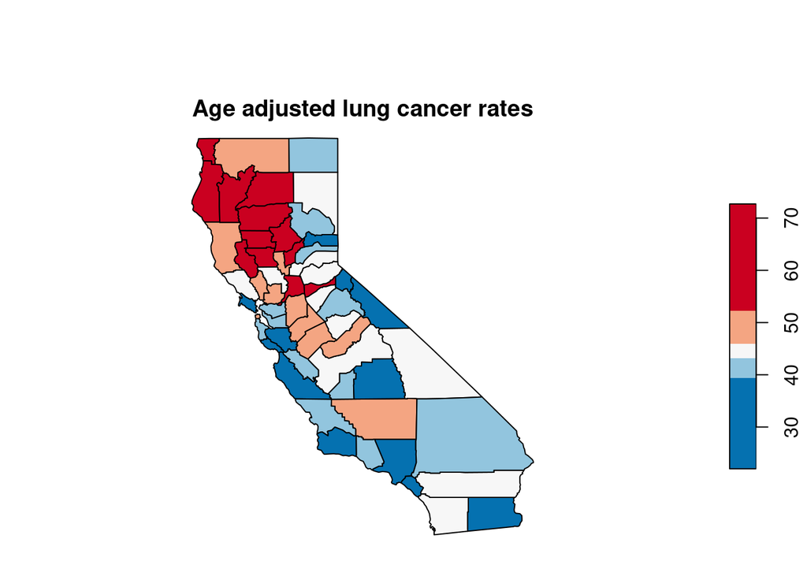

```r
yFitPosteriorMedians <- CI_yFit[,grep("50%", colnames(CI_yFit))]
caCountySF$ModelFitted <- yFitPosteriorMedians
caCountySF$ObsData <- Y
brksModelFitted = quantile(caCountySF$ModelFitted, c(0, 0.2, 0.4, 0.6, 0.8, 1))
brksObsData = quantile(caCountySF$ObsData, c(0, 0.2, 0.4, 0.6, 0.8, 1))

colorPalette = rev(brewer.pal(5,"RdBu"))

par(mfrow=c(1,2), oma = c(0,0,4,0) + 0.1, mar = c(0,0,1,0) + 0.1)

plot(caCountySF["ObsData"], pal = colorPalette, breaks = brksObsData, main = "Age adjusted lung cancer rates")
```

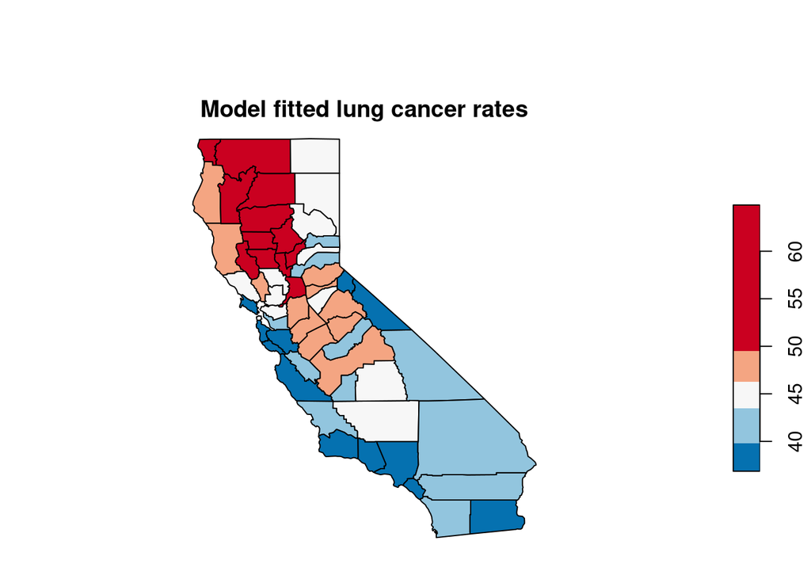

```r
plot(caCountySF["ModelFitted"], pal = colorPalette, breaks = brksModelFitted, main = "Model fitted lung cancer rates")
```

17. Model assessment: How good is this model? Is it “adequate”? Find the correlation between the model fitted values and the observed data. Then plot fitted values against raw data

```r
cor(Y, yFitPosteriorMedians) ## correlation between observed and model fitted values
```

```
## [1] 0.8871265
```

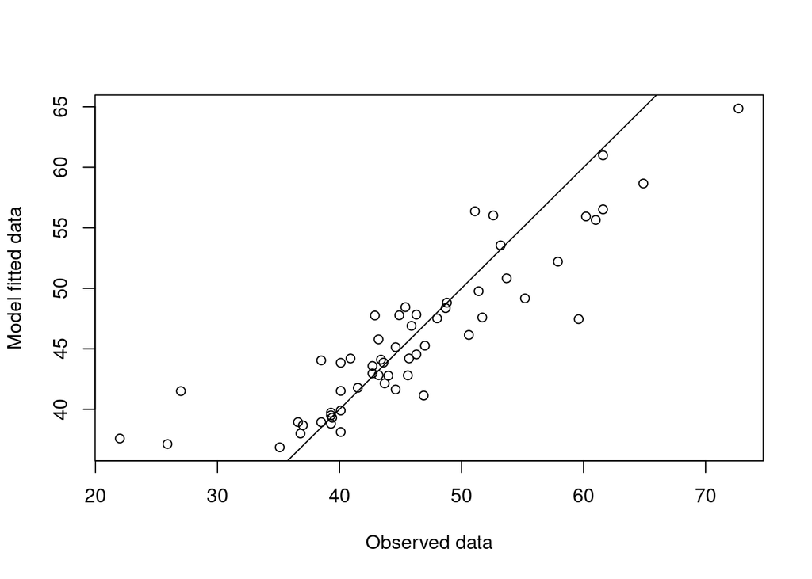

```r
plot(Y, yFitPosteriorMedians, xlab="Observed data", ylab="Model fitted data")
abline(0,1) ## adds the 45 degree (y=x) line to identify departures of fitted values from observations.
```

18. Our next step will be to assign a score for this model based upon the posterior distribution of fitted values. This distribution is $p(yFit \mid Y)$ and the resulting model fitted values are referred to as model replicated data. We first extract the posterior samples of “yFit” from “samps”.

```r
yFitSamps <- samps[,grep("yFit", colnames(samps))]
```

19. We define a goodness of fit measure “G” based on the sum of squared differences between the observations and the means of the replicated data for each data point.

```r
G <- sum((Y - colMeans(yFitSamps))^2)
G
```

```
## [1] 1393.372
```

20. We define a measure of penalty “P” that penalizes the complexity of the model based upon sum of the variances of the replicated data for each data point.

```r
P <- sum(apply(yFitSamps, 2, function (x) {var(x)} ))
P
```

```
## [1] 2902.941
```

21. Finally, we define a model assessment score “D=G+P” for this model. This score is useful for model comparisons. The smaller the score, the better the model.

```r
D <- G+P
D
```

```
## [1] 4296.313
```

22. Let us compare the D score of the spatial model with that of a simple linear regression model. We will again run 3 chains in our MCMC algorithm. We will need initial values for the model parameters, specify model parameters to monitor and run the model following essentially the same steps as for the spatial model. We run the code in one example block for convenience. You are, by now, quite familiar with these steps so a bit of quick documentation will not hurt.

```r
inits = list(
         list(beta=rep(0,times=p), tausq=1.0, yFit = rep(0, times=N)),
         list(beta=rep(-100, times=p), tausq=1.0, yFit = rep(0, times=N)),
         list(beta=rep(100,times=p), tausq=1.0, yFit = rep(0, times=N))
)

model.parameters = c("beta", "tausq", "sigma", "yFit")

m2 <- jags.model("../src/model_jags_simpleLM.txt", data=jagsDataSimpleLM, inits = inits, n.chains=nChains, n.adapt = nAdapt, quiet=TRUE)

update(m2, n.iter=nBurn)
```

[output not shown]

```r
m2.out <- coda.samples(model=m2, variable.names=model.parameters, n.iter=nSamp)
```

[output not shown]

```r
samps <- do.call(rbind, m2.out)

credibleIntervals <- t(apply(samps, 2, function(x){quantile(x, c(0.50, 0.025, 0.975))}))
CI_yFit <- credibleIntervals[grep("yFit", rownames(credibleIntervals)),]
yFitPosteriorMedians <- CI_yFit[,grep("50%", colnames(CI_yFit))]
cor(Y, yFitPosteriorMedians) ## correlation between observed and model fitted values
```

```
## [1] 0.6208844
```

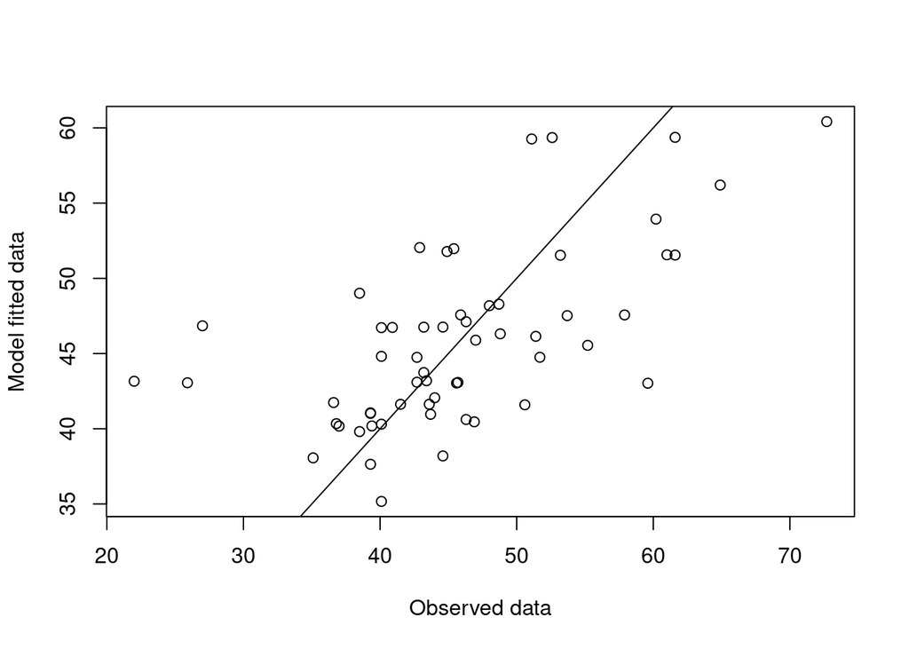

```r
plot(Y, yFitPosteriorMedians, xlab="Observed data", ylab="Model fitted data")
abline(0,1) ## adds the 45 degree (y=x) line to identify departures of fitted values from observations.
```

```r
yFitSamps <- samps[,grep("yFit", colnames(samps))]

G <- sum((Y - colMeans(yFitSamps))^2)
G
```

```
## [1] 3027.782
```

```r
P <- sum(apply(yFitSamps, 2, function (x) {var(x)} ))
P
```

```
## [1] 3366.994
```

```r
D <- G+P
D
```

```
## [1] 6394.776
```

Conclusion: Spatial model is clearly preferred due to its substantially lower D score.